# Investigating the association of Cognitive skills and drawing comparisons between male and female performance

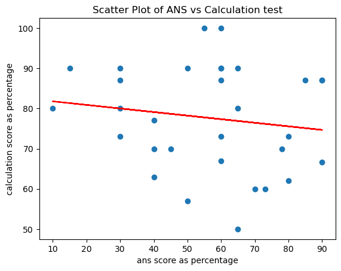

```
Spearman's rank correlation coefficient: -0.20026562730784775
p-value: 0.2800530107245732
```

```python
import pandas as pd
import matplotlib.pyplot as plt
import numpy as np

# Import data from CSV file
data = pd.read_csv('ans_vs_calculation.csv')

# Extract x and y values from the data
x = data['ans']
y = data['calcu']

# Create scatter plot
plt.scatter(x, y)

# Add labels and title
plt.xlabel('ANS result as a percentage value')
plt.ylabel('Calcution test result as a percentage value')
plt.title('Scatter Plot')


# Calculate the line of best fit
m, b = np.polyfit(x, y, 1)
line = m * x + b

# Add the line of best fit to the plot
plt.plot(x, line, color='red')

# Add labels and title
plt.xlabel('ans score as percentage')
plt.ylabel('calculation score as percentage')
plt.title('Scatter Plot of ANS vs Calculation test')

plt.show()

data = pd.read_csv('ans_vs_calculation.csv')

# Extract the columns from the data
x = data['ans']
y = data['calcu']

# Calculate the Spearman's rank correlation coefficient
correlation, p_value = spearmanr(x, y)

# Print the correlation coefficient
print("Spearman's rank correlation coefficient:", correlation)
print("p-value:", p_value)
```

**Hypothesis B - Can we detect any significant difference between the scores of males and females across our cognitive tests?**

**Null Hypothesis:** Male and female users would have the same performance due to the significance of these cognitive systems in humans.

**Alternative Hypothesis:** Males and females would perform differently across the cognitive test.

**Box plots**

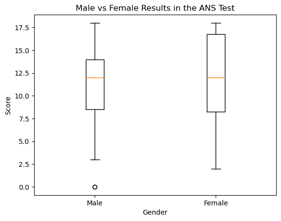

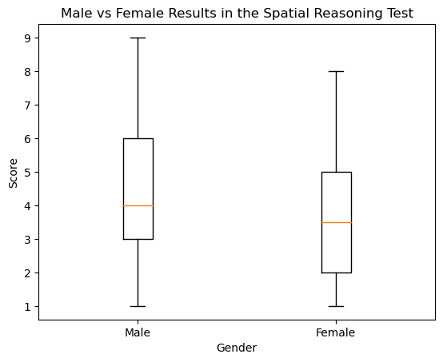

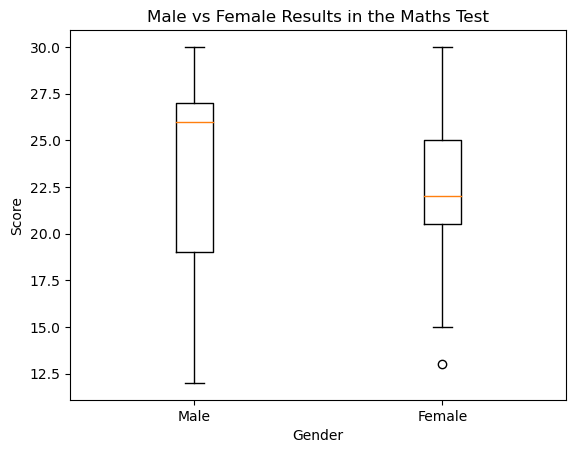

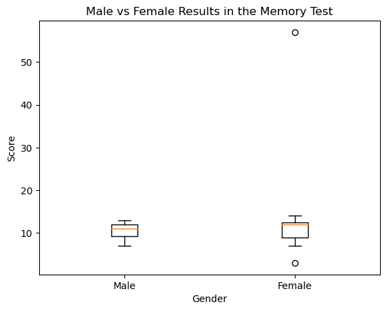

```python
import matplotlib.pyplot as plt

# ANS Test
male_scores_ans = [14, 8, 16, 13, 11, 14, 10, 18, 10, 8, 6, 0, 10, 12, 14, 12, 3, 12, 0, 13, 14, 16]
female_scores_ans = [18, 9, 6, 17, 6, 6, 18, 12, 13, 17, 12, 2, 12, 12, 16, 10, 18, 8]
fig, ax = plt.subplots()
ax.boxplot([male_scores_ans, female_scores_ans], labels=['Male', 'Female'])
plt.title("Male vs Female Results in the ANS Test")
plt.xlabel("Gender")
plt.ylabel("Score")

# Spatial Reasoning Test
male_scores = [1, 3, 6, 2, 5, 8, 5, 4, 3, 2, 3, 6, 8, 4, 3, 4, 9, 8, 4, 5]
female_scores = [2, 3, 6, 2, 5, 4, 7, 2, 1, 3, 2, 4, 8, 3, 5, 4]
fig, ax = plt.subplots()
ax.boxplot([male_scores, female_scores], labels=['Male', 'Female'])
plt.title("Male vs Female Results in the Spatial Reasoning Test")
plt.xlabel("Gender")
plt.ylabel("Score")

# Maths Test
male_scores_maths = [21, 27, 24, 22, 12, 19, 26, 27, 26, 18, 30, 26, 16, 17, 30, 27, 27, 27, 19]
female_scores_maths = [22, 24, 30, 26, 26, 27, 22, 22, 20, 15, 24, 27, 13, 20, 22, 15, 21, 23, 24]
fig, ax = plt.subplots()
ax.boxplot([male_scores_maths, female_scores_maths], labels=['Male', 'Female'])
plt.title("Male vs Female Results in the Maths Test")
plt.xlabel("Gender")
plt.ylabel("Score")


# Memory Test
male_scores_memory = [11, 12, 7, 8, 9, 12, 13, 13, 10, 11]
female_scores_memory = [12, 10, 13, 12, 12, 11, 57, 8, 7, 3, 14]
fig, ax = plt.subplots()
ax.boxplot([male_scores_memory, female_scores_memory], labels=['Male', 'Female'])
plt.title("Male vs Female Results in the Memory Test")
plt.xlabel("Gender")
plt.ylabel("Score")


plt.show()
```

By looking at the box plot, males and females have a similar median score in tests except for the maths test having males performing much better. Also, the male has a larger range of results in spatial reasoning tests and maths tests.